# Rosely test with random data

This notebook tests the statistical properties of Rosely, especially ascertained *t*-test. It also contains various senarios to show how the *p*-values are systematically biased.

Loading Rosely and other tools:

```python
import sys, imp, time, pandas as pd, re, operator
%pylab inline
import scipy.stats as ss
if 'rudolphLab/scripts' not in sys.path: sys.path.insert(0, '/Users/jiangnan/Documents/rudolphLab/scripts')
import pandas as pd
import rosely
imp.reload(rosely)
from rosely import *
```

```
Rosely version: 1.3.0
import time: 2019-05-23 20:04:11.499009+02:00
Rosely version: 1.3.0
import time: 2019-05-23 20:04:11.502355+02:00
```

### Test the distribution of the sum of two random normal variables

First, test variance normalization with power transformation to minimize the gap between mean and median.

```
(0.78950685089675521,
 0.79518893873889784,
 0.99976904385751564,
 0.32348605414752835)
```

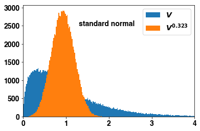

```python
V = 1; n = 4
d  = random.normal(0, V**0.5, size=(100000, n))
dg = random.normal(0, V**0.5, size=(100000, n))
dall = d + dg
v    = var(d,    axis=1, ddof=1)
Vall = var(dall, axis=1, ddof=1)
y, x, _ = hist(v, 500, label='$V$');
Valla, a = mean_median_norm(Vall)
va = v**a
hist(va, 100, label='$V^{{{:.3f}}}$'.format(a));
xlim([0, 4]);
legend()
text(1.3, 2500, 'standard normal')
median(v), mean(va)**(1/a), mean(v), a
```

## Test the proximity between simulated and formula-calculated mean and variance of transformed variances

```python
from scipy.integrate import quad
ms2a  = quad(itg.ms2fs2a  , 0, 100, points=[1], args=(n, V, a))[0]
print('mean(V**a):', mean(va))
print('Expc(V**a):', ms2a)
Vsmpl = quad(itg.Vsmplfs2a, 0, 100, points=[1], args=(n, V, a, ms2a))[0]
print('Variance(V**a):', var(va))
print('ExpctVar(V**a):', Vsmpl)
```

```
mean(V**a): 0.928546248866
Expc(V**a): 0.9281439075249474
Variance(V**a): 0.068028581391
ExpctVar(V**a): 0.0684806881833319
```

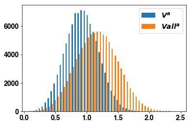

```python
# hist(Vall, 200);
hist([va, Valla], 50);
legend(['$V^ a$', '$Vall^ a$'])
```

## Test sample variance density functions

Sampling variance density function fs2lV can be found at http://mathworld.wolfram.com/SampleVarianceDistribution.html

However, note that N has been changed into n-1 here when appearing together with V.

```python
from scipy.special import gammaln, gammainc, gamma, polygamma
from scipy.integrate import quad
def fs2lV(s2, n, V):
    return exp((n-1)/2 * log((n-1)/2/V) - gammaln((n-1)/2) + (n-3)/2*log(s2) - (n-1)*s2/2/V)
def fs2alV(s2a, n, V, a):
    return fs2lV(s2a**(1/a), n, V) / (a*s2a**((a-1)/a))
```

```
Integral close to 1 indicates correctness of the equation: 0.9999999999999443
```

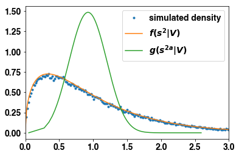

```python
s2 = linspace(0.0001, 19, 1000)
fs2 = fs2lV(s2, n, V)
plot((x[1]-x[0])/2+x[:-1], y/max(y)*max(fs2), '.', label='simulated density')
plot(s2, fs2, label='$f(s^2|V)$')
print('Integral close to 1 indicates correctness of the equation:', quad(fs2lV, 0, 40, args=(n, V))[0])
plot(s2**a, fs2alV(s2**a, n, V, a), label='$g(s^{2a}|V)$')
legend(); xlim([0, 3]);
```

### Test for the equivalence of *t*-test and *z*-test with integration over variance for *p*-value calculation

```python
def fVls2(v, n, s2=1): # Oliphant 2006
    nC = s2 * (n - 1)
    return (nC/2)**((n-1)/2) / gamma((n-1)/2) / v**((n+1)/2) * exp(-nC/2/v)

for n in [3, 5]:
    for m in [1, 2]:
        print('n =', n, ' m =', m, ':',  ss.t.cdf(-m*n**0.5, n-1))
        print('n =', n, ' m =', m, ':',  quad(lambda v: ss.norm.cdf(-m*(n/v)**0.5) * fVls2(v, n), 0, Inf)[0])
quad(fVls2, 0, Inf, args=(3,))[0]
```

```
n = 3  m = 1 : 0.112701665379
n = 3  m = 1 : 0.11270166537923798
n = 3  m = 2 : 0.0370899501137
n = 3  m = 2 : 0.037089950113724054
n = 5  m = 1 : 0.04450467125
n = 5  m = 1 : 0.044504671250042455
n = 5  m = 2 : 0.00552824669673
n = 5  m = 2 : 0.005528246696724729
```

```
1.0000000000000002
```

```python
def cdfs2alV(s, n, V, a):
    return gammainc((n-1)/2, (n-1)*s**(1/a)/(2*V))
def means2a(n, V, a):
    return exp(gammaln((n-1)/2+a) - gammaln((n-1)/2)  + a * log(2*V/(n-1)))
def vars2a(n, V, a, y0=0):
    G  = gammaln((n-1)/2)
    Gs = gammaln((n-1)/2+a)
    return (2*V/(n-1))**(2*a) * (exp(gammaln((n-1)/2+2*a)-G) - exp(2*(Gs-G))) - y0
def vars2a_aprx(n, V, a, y0=0):
    psi1 = a**2 * polygamma(1, (n-1)/2)
    psi2 = a**3 * polygamma(2, (n-1)/2)
    psis = psi1 + psi2
    return (2*V/(n-1))**(2*a) * exp(2*a*polygamma(0, (n-1)/2) + psi1 + psi2/3) * (psis + psis**2/2) - y0
```

```python
(means2a(3, 1, 1e-5)) ** (1/1e-5)
```

```
0.56146410138247749
```

```python
print('Compare the result of closed form means2a and numeric integration for mean of s2^a with different n:')
for n in [2, 3]:
    print(means2a(n, V, a))
    print(quad(lambda x, n, V, a: x*itg.fs2alV(x, n, V, a), 0, 100, args=(n, V, a))[0])
```

```
Compare the result of closed form means2a and numeric integration for mean of s2^a with different n:
0.804027949496
0.8040279494956301
0.894188952948
0.8941889529558019
```

```python
print('Cummulative distribution function of f(s2a|V):')
s2a = 0.35
print(cdfs2alV(s2a, n, V, a))
print(quad(fs2alV, 0, s2a, args=(n, V, a))[0])
```

```
Cummulative distribution function of f(s2a|V):
0.0382063286042
0.038206328603718906
```

```python
print('Compare the result of closed form vars2a and numeric integration for variance of s2^a with different n:')
for n in [2, 3, 20]:
    print('n = ', n, ':', vars2a(n, V, a))
    print('n = ', n, ':', quad(lambda x, n, V, a: (x-means2a(n, V, a))**2*fs2alV(x, n, V, a),
                               0, 100, args=(n, V, a))[0])
```

```
Compare the result of closed form vars2a and numeric integration for variance of s2^a with different n:
n =  2 : 0.178726082374
n =  2 : 0.17872608237433696
n =  3 : 0.100088270633
n =  3 : 0.10008827063210736
n =  20 : 0.0110199602002
n =  20 : 0.01101996020024471
```

```
('peak n:', 1.1401402401401401, 1, 0.32348605414752835)
```

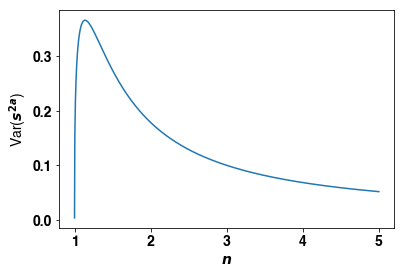

```python
ns = linspace(1, 5, 1000)+1e-7
plot(ns, vars2a(ns, V, a))
xlabel('$n$'); ylabel('Var($s^{2a}$)')
'peak n:', ns[argmax(vars2a(ns, V, a))], V, a
```

## Test approximate solution for *n*<sub>0</sub>

```python
from scipy.optimize import fsolve
a = 1/4; V = 1
evs = []; ens = []
for evs2 in [1e-2, 1e-3, 1e-4, 1e-5, 1e-8, 1e-10]:
    n0 = 2*a**2/(evs2/V**(2*a)) + 1
    En = fsolve(vars2a, n0, args=(V, a, evs2))[0]
    print('En1:', En)
    En = fsolve(vars2a_aprx, n0, args=(V, a, evs2))[0]
    print('En2:', En)
    print(En, vars2a(En, V, a, 0), vars2a_aprx(En, V, a, 0), n0, '\n')
    evs.append(evs2); ens.append(En)
```

```
En1: 13.6696041015
En2: 13.6429027746
13.6429027746 0.0100213750221 0.01 13.5

En1: 126.185773237
En2: 126.183389589
126.183389589 0.00100001906931 0.001 126.0

En1: 1251.18732819
En2: 1251.18709233
1251.18709233 0.000100000019967 0.0001 1251.0

En1: 12500.9958228
En2: 12501.1874593
12501.1874593 9.99999349079e-06 1e-05 12500.999999999998

En1: 12500001.0
En2: 12500001.1875
12500001.1875 4.47034817911e-08 1e-08 12500001.0

En1: 1250000001.0
En2: 1250000001.19
1250000001.19 1.90734620192e-06 1e-10 1250000001.0
```

## Create and test a difficult $z$-score distribution for LFDR fitting

```
iterations:0 r0:0.130, re:0.347, a:0.79034 lsq para:[ 0.0728531  0.5097329]
iterations:1 r0:0.054, re:0.291, a:0.68670 lsq para:[ 0.00406884  0.1424116 ]
iterations:2 r0:0.028, re:0.271, a:0.65597 lsq para:[-0.00769266  0.10458044]
iterations:3 r0:0.022, re:0.267, a:0.64907 lsq para:[-0.00989174  0.10156369]
iterations:4 r0:0.020, re:0.265, a:0.64700 lsq para:[-0.01047965  0.1016541 ]
iterations:5 r0:0.019, re:0.265, a:0.64611 lsq para:[-0.01075042  0.10145389]
finetune para: [0.6389845736541514, -1.0025457890051582e-05, 2.0]  raw aa: 0.646114486767
total iterations:6 r0:0.019, re:0.264, last a:0.64611
power of p-values: fit: 0.6390, base: 1.0000, final:0.6390
```

```
array([  2.22755329e-186,   6.37038577e-121,   4.82756726e-049,
         5.75286950e-001,   7.49463779e-001])
```

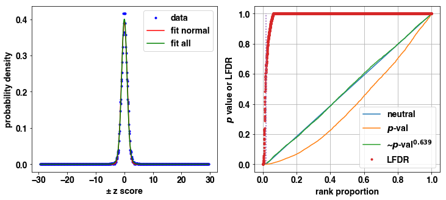

```python
ps = random.uniform(size=(5000,))
ps[:200] **= 5
ps **= 1.5
ps[0] = 1e-299; ps[1] = 1e-199; ps[2] = 1e-85
_, lfdr, _ = neup(ps, nbins=50);
lfdr[:5]
```

```
iterations:0 r0:0.130, re:0.347, a:0.79034 lsq para:[ 0.0728531  0.5097329]
iterations:1 r0:0.054, re:0.291, a:0.68670 lsq para:[ 0.00406884  0.1424116 ]
iterations:2 r0:0.028, re:0.271, a:0.65597 lsq para:[-0.00769266  0.10458044]
iterations:3 r0:0.022, re:0.267, a:0.64907 lsq para:[-0.00989174  0.10156369]
iterations:4 r0:0.020, re:0.265, a:0.64700 lsq para:[-0.01047965  0.1016541 ]
iterations:5 r0:0.019, re:0.265, a:0.64611 lsq para:[-0.01075042  0.10145389]
finetune para: [0.6389845736541514, -1.0025457890051582e-05, 2.0]  raw aa: 0.646114486767
total iterations:6 r0:0.019, re:0.264, last a:0.64611
power of p-values: fit: 0.6390, base: 1.0000, final:0.6390
```

```
array([  6.97250907e-186,   3.18659160e-121,   2.48929284e-049,
         5.89426873e-001,   7.62512365e-001])
```

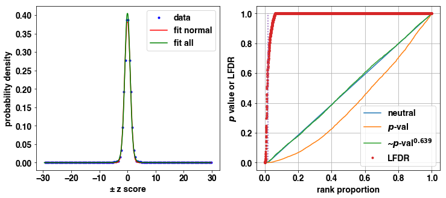

```python
_, lfdr, _ = neup(ps, nbins=10, df_fit=5);
lfdr[:5]
```

```python
ss.norm.ppf([1e-85, 1e-320, 1e-200])
```

```
array([-19.58690091, -38.26912534, -30.20559418])
```

## Create normally distributed data for *t*-test

```python
N = 2000; ntop = int(N*0.05); pops = {}

def create_simu_data(mdif, nrep, ntechrep=1, prop=0.05, gradual=False, normal=False):
    simudata = pd.DataFrame({(i,j):[] for i in range(2) for j in range(nrep)})
    if normal: mdif = mdif + random.normal(size=(N,))
    for i in range(2*nrep*ntechrep):
        group = i//(nrep*ntechrep); sample = i % (nrep*ntechrep)
        if sample < nrep:
            r = random.normal(0, 1, size=(N,))
            if group==0:
                top = int(N*prop)
                if gradual: r[:top] += 2 * mdif * (1 + array(range(top))) / top
                elif normal: r[:top] += mdif[:top]
                else: r[:top] += mdif
        else:
            r = simudata[(group, sample % nrep)]
        simudata[(group, sample)] = r
    return simudata

def one_cycle(mdif, nrep, ntechrep=1):
    simudata = create_simu_data(mdif, nrep, ntechrep)
    x = simudata[0].values
    y = simudata[1].values
    _, ps1 = ss.ttest_ind(x, y, equal_var=True , axis=1)
    _, ps2 = ss.ttest_ind(x, y, equal_var=False, axis=1)
    z = (mean(x, axis=1) - mean(y, axis=1)) / (2/nrep)**0.5; psz = ss.norm.cdf(-abs(z)) * 2
    # http://www.stat.ucla.edu/~cochran/stat10/winter/lectures/lect21.html
    # or https://www.cliffsnotes.com/study-guides/statistics/univariate-inferential-tests/two-sample-z-test-for-comparing-two-means

    ps, zs, vbs = ascertained_ttest(simudata, pre_neutralize=True, equalV=False, weights=False) # No weights as other tests
    if pops:
        neupvals, LFDR, pop = neup(ps, minr0=0.0, with_plot=False)
        pops['ascertained'].append(pop); LFDRs['ascertained'].append(LFDR); rawps['ascertained'].append(ps)
        for ps, t in zip([ps1, ps2, psz], ['Student', 'Welch', '$z$-test']):
            rawps[t].append(ps)
            nps, LFDR, pop = neup(ps, minr0=0.0, with_plot=False)
            pops[t].append(pop); LFDRs[t].append(LFDR)
    return simudata, vbs

def compute(mdif, nrep, ntechrep = 1):
    for nt in range(100):
        simudata, vbs = one_cycle(mdif, nrep)
        print(nt, end=' ')
    nTs = {} # number of true discoveries (consistent with rank)
    for t in LFDRs:
        nTs[t] = []
        for ps in rawps[t]:
            idx = array(ps).argsort()
            nTs[t].append(sum(idx[:ntop] < ntop))
    print('\nmean_dif=', mdif, ' n_rep=', nrep)
    print('               ascertained            Student              Welch             z-test')
    print('mean nTs:', (mean(nTs['ascertained'])/ntop, mean(nTs['Student'])/ntop, mean(nTs['Welch'])/ntop, mean(nTs['$z$-test'])/ntop))
    print('std  nTs:', ( std(nTs['ascertained'])/ntop,  std(nTs['Student'])/ntop,  std(nTs['Welch'])/ntop,  std(nTs['$z$-test'])/ntop))
    ETs = {} # estimated true discoveries
    Ds = {}
    for t in LFDRs:
        ETs[t] = []
        for LFDR in LFDRs[t]:
            lfdr = array(sorted(LFDR)[:ntop])
            ETs[t].append(sum(1 - lfdr))
    print('mean ETs:', (mean(ETs['ascertained'])/ntop, mean(ETs['Student'])/ntop, mean(ETs['Welch'])/ntop, mean(ETs['$z$-test'])/ntop))
    print('std  ETs:', ( std(ETs['ascertained'])/ntop,  std(ETs['Student'])/ntop,  std(ETs['Welch'])/ntop,  std(ETs['$z$-test'])/ntop))
    return nTs, ETs, LFDRs, vbs
```

### Fig. 1a

```python
simudata, vbs1 = one_cycle(2, 3)
figure(figsize=(2.3,1.4))
v = vbs1['mvns'][1]['v']
hist(v, 50, label='$s^{2}$');
Va, a = mean_median_norm(v)
hist(Va, 30, label=r'$s^{2e}$');
legend(fontsize=12)
xlim([0, 5])
xticks([]);
yticks([]);
xlabel('$s^{2}$  or  $s^{2e}$', fontsize=16)
ylabel('frequency', fontsize=16)
text(0.4, 90, 'a', fontsize=16);
```

[output not shown]

```
0.976;
```

## Supplementary Figure 1

```
0.992; 0 1.007; 1 0.98; 2 1.029; 3 0.979; 4 1.011; 5 0.956; 6 0.928; 7 1.002; 8 0.994; 9 0.962; 10 1.009; 11 0.955; 12 0.981; 13 0.937; 14 0.944; 15 0.916; 16 0.939; 17 0.986; 18 1.018; 19 0.942; 20 0.983; 21 0.969; 22 0.998; 23 0.996; 24 0.981; 25 1.016; 26 0.998; 27 0.959; 28 0.97; 29 0.934; 30 0.…
mean_dif= 2  n_rep= 3
               ascertained            Student              Welch             z-test
mean nTs: (0.56630000000000003, 0.37390000000000001, 0.36369999999999997, 0.57320000000000004)
std  nTs: (0.045577516386920432, 0.044942073828429414, 0.047321348247910268, 0.042447143602367413)
mean ETs: (0.38194592883157769, 0.11066137170327414, 0.013903790685657814, 0.50878138042882637)
std  ETs: (0.10146527166796225, 0.10291921459269936, 0.034359221185141578, 0.073590665023351945)
1.01; 0 1.002; 1 0.976; 2 0.937; 3 1.001; 4 1.007; 5 0.991; 6 0.966; 7 1.016; 8 1.001; 9 0.939; 10 1.006; 11 0.98; 12 0.95; 13 0.945; 14 1.01; 15 1.016; 16 0.942; 17 0.993; 18 0.936; 19 1.016; 20 0.949; 21 0.999; 22 1.018; 23 1.003; 24 0.993; 25 1.005; 26 1.026; 27 1.001; 28 0.98; 29 0.93; 30 0.93; …
mean_dif= 4  n_rep= 3
               ascertained            Student              Welch             z-test
mean nTs: (0.96209999999999996, 0.73209999999999997, 0.70849999999999991, 0.96409999999999996)
std  nTs: (0.01557530096017409, 0.033594493596421429, 0.033387872049593099, 0.013645145656972666)
mean ETs: (0.95808453852658348, 0.66920972422854563, 0.43319926830353223, 0.9773492764518299)
std  ETs: (0.015625873331950365, 0.077753549408482572, 0.085320777029709235, 0.0078121325362383231)
1.003; 0 0.933; 1 0.929; 2 0.987; 3 0.985; 4 0.918; 5 0.992; 6 0.952; 7 0.972; 8 0.989; 9 1.016; 10 0.979; 11 0.914; 12 0.983; 13 0.97; 14 1.003; 15 0.988; 16 1.006; 17 0.975; 18 0.959; 19 0.931; 20 0.992; 21 0.929; 22 0.967; 23 0.968; 24 1.011; 25 0.953; 26 0.982; 27 0.999; 28 0.997; 29 0.899; 30 0…
mean_dif= 2  n_rep= 6
               ascertained            Student              Welch             z-test
mean nTs: (0.81330000000000002, 0.70530000000000004, 0.70569999999999988, 0.81420000000000003)
std  nTs: (0.029225160393058586, 0.037774462272810713, 0.037155214977173792, 0.028711670101197528)
mean ETs: (0.78148847494286344, 0.65380036671603525, 0.59484604687729548, 0.81508005370494974)
std  ETs: (0.044276494150824887, 0.06233598440717155, 0.070194943890980244, 0.037524184382896598)
1.038; 0 1.032; 1 1.017; 2 1.043; 3 1.039; 4 1.004; 5 1.015; 6 1.033; 7 0.993; 8 0.979; 9 1.047; 10 0.987; 11 1.05; 12 1.061; 13 1.043; 14 1.036; 15 1.038; 16 1.025; 17 1.069; 18 1.021; 19 1.014; 20 1.012; 21 1.016; 22 1.027; 23 1.01; 24 1.017; 25 1.008; 26 1.018; 27 1.038; 28 1.04; 29 1.019; 30 1.0…
mean_dif= 0  n_rep= 3
               ascertained            Student              Welch             z-test
mean nTs: (0.050799999999999998, 0.0458, 0.046300000000000001, 0.049200000000000001)
std  nTs: (0.021756838005555865, 0.019554027718094294, 0.019321231844786707, 0.020721003836687065)
mean ETs: (0.005064577638699802, 0.02509617380376802, 0.00078221899295356746, 0.033663674120202415)
std  ETs: (0.015446253864091769, 0.03892020508201352, 0.0025379620661083258, 0.047037123999410409)
```

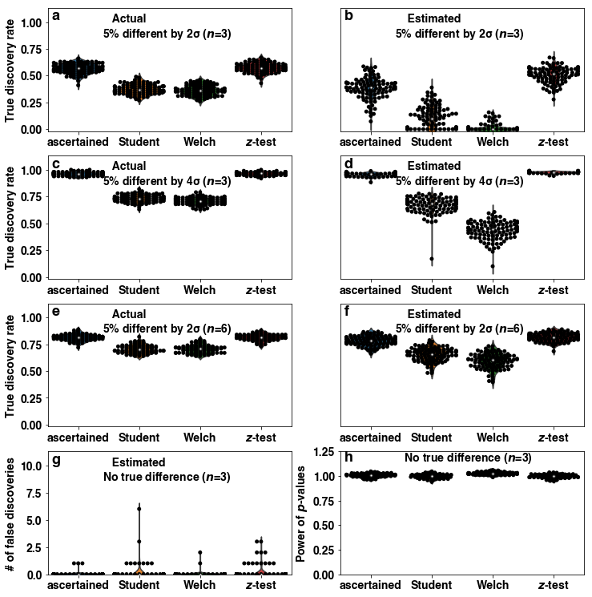

```python
import seaborn, pandas as pd
figure(figsize=(12,13))
order = ['ascertained', 'Student', 'Welch', '$z$-test']
for row, (mdif, nrep), names in zip(range(4), [(2, 3), (4, 3), (2, 6), (0, 3)],
                           [
                            ('   Actual\n5% different by 2σ ($n$=3)', '    Estimated\n5% different by 2σ ($n$=3)'),
                            ('   Actual\n5% different by 4σ ($n$=3)', '    Estimated\n5% different by 4σ ($n$=3)'),
                            ('   Actual\n5% different by 2σ ($n$=6)', '    Estimated\n5% different by 2σ ($n$=6)'),
                            ('   Estimated\nNo true difference ($n$=3)', '   No true difference ($n$=3)'),
                           ]):
#     if row<3:continue
    pops  = {'Student':[], 'ascertained':[], 'Welch':[], '$z$-test':[]}
    rawps = {'Student':[], 'ascertained':[], 'Welch':[], '$z$-test':[]}
    LFDRs = {'Student':[], 'ascertained':[], 'Welch':[], '$z$-test':[]}
    nTs, ETs, LFDRs, vbs = compute(mdif, nrep)
    for i, data in enumerate([nTs, ETs]):
        iax = 421 + row * 2 + i
        subplot(iax)
        if row==3 and i==1:
            seaborn.swarmplot (order=order, data=pd.DataFrame(pops), color='k', edgecolor="gray")
            seaborn.violinplot(order=order, data=pd.DataFrame(pops))
            ylim([0, 1.25])
            ylabel('Power of $p$-values', fontweight='bold')
            text(0.4, 1.15, names[i])
            text(-0.44, 1.15, 'h', fontsize=18)
        else:
            if row==3:
                data = {}
                for t in LFDRs:
                    data[t] = []
                    for lfdr in LFDRs[t]:
                        data[t].append(sum(lfdr<0.4)*ntop)
            seaborn.swarmplot (order=order, data=pd.DataFrame(data)/ntop, color='k', edgecolor="gray")
            seaborn.violinplot(order=order, data=pd.DataFrame(data)/ntop)
            ymax = 1 + (row==3)*9
            ylim([-0.019, 1.13 * ymax])
            if i==0: ylabel(['# of false discoveries', 'True discovery rate'][int(row<3)], fontweight='bold')
            else: yticks([])
            text(0.4, 0.85 * ymax, names[i])
            text(-0.44, 1.02 * ymax, 'abcdefgh'[row*2+i], fontsize=18)
```

```python
# data = {}
# for t in LFDRs:
#     data[t] = []
#     for lfdr in LFDRs[t]:
#         data[t].append(sum(lfdr<0.3))
for t in LFDRs:
    print(t, sum([sum(lfdr<0.3) for lfdr in LFDRs[t]]))
```

```
Student 5
ascertained 2
Welch 3
$z$-test 8
```

## Supplementary Figure 2

### How do technical replicates distort p-value distribution in Student's t-test?

Note: there are no true differences. All discoveries are false positive.

```python
N = 10000
data = create_simu_data(mdif=0, nrep=3, ntechrep=1)
_, ps1 = ss.ttest_ind(data[0].values, data[1].values, equal_var=True, axis=1)

data = create_simu_data(mdif=0, nrep=3, ntechrep=2)
_, ps2 = ss.ttest_ind(data[0].values, data[1].values, equal_var=True, axis=1)

data = create_simu_data(mdif=0, nrep=3, ntechrep=3)
_, ps3 = ss.ttest_ind(data[0].values, data[1].values, equal_var=True, axis=1)

data = create_simu_data(mdif=0, nrep=3, ntechrep=10)
_, ps10 = ss.ttest_ind(data[0].values, data[1].values, equal_var=True, axis=1)
```

```
iterations:0 r0:0.000, re:0.250, a:1.01347 lsq para:[ 0.29436329 -0.03172518]
finetune para: [1.0033495152457086, 0.0, 2.0]  raw aa: 1.00671024974
total iterations:0 r0:0.000, re:0.250, last a:1.01347
power of p-values: fit: 1.0033, base: 1.0000, final:1.0033
iterations:0 r0:0.231, re:0.424, a:0.78182 lsq para:[ 0.02965144  0.05745746]
iterations:1 r0:0.135, re:0.351, a:0.65186 lsq para:[-0.00761916 -0.026702  ]
iterations:2 r0:0.063, re:0.297, a:0.57155 lsq para:[-0.03496764 -0.14207317]
iterations:3 r0:0.014, re:0.261, a:0.52456 lsq para:[-0.04978734 -0.16604576]
iterations:4 r0:0.000, re:0.250, a:0.51185 lsq para:[-0.05468716 -0.17727865]
finetune para: [0.48453057710287911, -0.38228390973764315, 1.9993862968403928]  raw aa: 0.511854598823
total iterations:4 r0:0.000, re:0.250, last a:0.51185
power of p-values: fit: 0.4845, base: 1.0000, final:0.4845
iterations:0 r0:0.343, re:0.507, a:0.72031 lsq para:[-0.02587258 -0.38010198]
iterations:1 r0:0.228, re:0.421, a:0.56621 lsq para:[-0.03523702 -0.24024789]
iterations:2 r0:0.139, re:0.354, a:0.47516 lsq para:[-0.05960405 -0.30759585]
iterations:3 r0:0.074, re:0.306, a:0.42188 lsq para:[-0.07425002 -0.31425011]
iterations:4 r0:0.038, re:0.278, a:0.39555 lsq para:[-0.07888161 -0.25510919]
iterations:5 r0:0.024, re:0.268, a:0.38576 lsq para:[-0.0827596  -0.25624397]
iterations:6 r0:0.018, re:0.264, a:0.38223 lsq para:[-0.08444677 -0.26023138]
iterations:7 r0:0.016, re:0.262, a:0.38071 lsq para:[-0.08511815 -0.26100579]
iterations:8 r0:0.015, re:0.261, a:0.37991 lsq para:[-0.08549288 -0.26169166]
iterations:9 r0:0.015, re:0.261, a:0.37964 lsq para:[-0.08561271 -0.26184428]
iterations:10 r0:0.015, re:0.261, a:0.37955 lsq para:[-0.08565301 -0.26190013]
finetune para: [0.34385936708347281, -0.41418185269558061, 1.9990533510391468]  raw aa: 0.379548893381
total iterations:11 r0:0.015, re:0.261, last a:0.37955
power of p-values: fit: 0.3439, base: 1.0000, final:0.3439
iterations:0 r0:0.588, re:0.691, a:0.56460 lsq para:[ 0.03937637 -0.00620832]
iterations:1 r0:0.457, re:0.592, a:0.38079 lsq para:[-0.00366089 -0.08650649]
iterations:2 r0:0.325, re:0.494, a:0.27359 lsq para:[-0.05465842 -0.15818697]
iterations:3 r0:0.206, re:0.404, a:0.20941 lsq para:[-0.08540607 -0.09842527]
iterations:4 r0:0.120, re:0.340, a:0.17549 lsq para:[-0.1025851  -0.03763414]
iterations:5 r0:0.075, re:0.306, a:0.16170 lsq para:[-0.12310424 -0.08713333]
iterations:6 r0:0.053, re:0.290, a:0.15533 lsq para:[-0.12826739 -0.08388916]
iterations:7 r0:0.046, re:0.285, a:0.15340 lsq para:[-0.1296903  -0.08161088]
iterations:8 r0:0.045, re:0.283, a:0.15287 lsq para:[-0.13013509 -0.08127563]
iterations:9 r0:0.043, re:0.282, a:0.15249 lsq para:[-0.13043223 -0.08090073]
iterations:10 r0:0.043, re:0.282, a:0.15242 lsq para:[-0.13049273 -0.08083265]
finetune para: [0.11934710233275958, -0.39003631494633528, 1.9983463445502252]  raw aa: 0.15241916618
total iterations:11 r0:0.043, re:0.282, last a:0.15242
power of p-values: fit: 0.1193, base: 1.0000, final:0.1193
```

```
'Supplementary Figure 2'
```

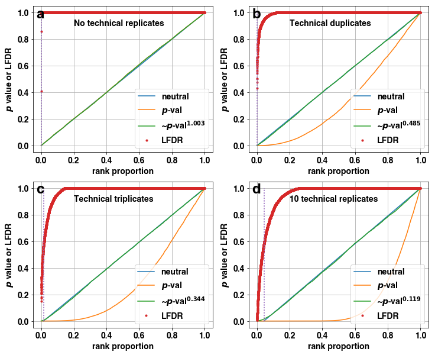

```python
figure(figsize=(12, 10))
subplot(221)
LFDRthr0 = 0.5; fine_tune = True
neup(ps1, LFDRthr0=LFDRthr0, minr0=0, subplot_label='a', plotLFDR=False, fine_tune=fine_tune);
text(0.2, 0.9, 'No technical replicates')

subplot(222)
neup(ps2, LFDRthr0=LFDRthr0, minr0=0, subplot_label='b', plotLFDR=False, fine_tune=fine_tune);
text(0.2, 0.9, 'Technical duplicates')

subplot(223)
neup(ps3, LFDRthr0=LFDRthr0, minr0=0, subplot_label='c', plotLFDR=False, fine_tune=fine_tune);
text(0.2, 0.9, 'Technical triplicates')

subplot(224)
neup(ps10, LFDRthr0=LFDRthr0, minr0=0, subplot_label='d', plotLFDR=False, fine_tune=fine_tune);
text(0.2, 0.9, '10 technical replicates')
'Supplementary Figure 2'
```

```
(0.074140795862335143, 3, 7.2302522896338572e-08, 1.0511776460184255e-12)
```

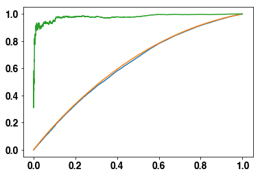

```python
def pdist(Ep, pop, n=2):
    t = ss.t.ppf(Ep/2, n)
    tb = t / pop**0.5
    p = 2 * ss.t.cdf(tb, n/pop)
    return log(p)
from scipy.optimize import curve_fit
Ep = array(range(1, len(ps10)+1))/len(ps10); pop = 0.1; n = 3
# pop, n = curve_fit(pdist, Ep, array(sorted(ps10))**0.1, p0=[0.2, 4], bounds=([0.001, 1], [4, 100]))[0]
pop,  = curve_fit(pdist, Ep, log(sorted(ps10)), p0=[0.2,], bounds=([0.001,], [4,]))[0]
plot(Ep, array(sorted(ps10))**pop)
plot(Ep, exp(pdist(Ep, pop, n))**pop)
plot(Ep, array(sorted(ps10))**pop/exp(pdist(Ep, pop, n))**pop)
i = 5
pop, n, exp(pdist(Ep[i], pop, n))/Ep[i]**10, sorted(ps10)[i]/Ep[i]**10
```

## Supplementary Figure 3

### How do technical replicates distort p-value distribution in ascertained t-test?

Note: there are no true differences. All discoveries are false positive.

```python
N = 10000
data1  = create_simu_data(mdif=0, nrep=3, ntechrep=1)
data2  = create_simu_data(mdif=0, nrep=3, ntechrep=2)
data3  = create_simu_data(mdif=0, nrep=3, ntechrep=3)
data10 = create_simu_data(mdif=0, nrep=3, ntechrep=10)
```

```python
weighted = False
aps1 , zs, vbs = ascertained_ttest(data1 , pre_neutralize=True, equalV=False, weights=weighted)
bp1 = vbs['base_pop']
aps2 , zs, vbs = ascertained_ttest(data2 , pre_neutralize=True, equalV=False, weights=weighted)
bp2 = vbs['base_pop']
aps3 , zs, vbs = ascertained_ttest(data3 , pre_neutralize=True, equalV=False, weights=weighted)
bp3 = vbs['base_pop']
aps10, zs, vbs = ascertained_ttest(data10, pre_neutralize=True, equalV=False, weights=weighted)
bp10 = vbs['base_pop']
```

```
1.027; 0.534; 0.377; 0.157;
```

```
iterations:0 r0:0.000, re:0.250, a:1.00064 lsq para:[ -6.82705307 -63.79442978]
finetune para: [0.99215179700116041, -5.146725925442297e-07, 2.0]  raw aa: 1.00032182769
total iterations:0 r0:0.000, re:0.250, last a:1.00064
power of p-values: fit: 0.9922, base: 1.0000, final:0.9922
iterations:0 r0:0.138, re:0.354, a:0.82078 lsq para:[-0.00812294 -0.12751977]
iterations:1 r0:0.034, re:0.276, a:0.68284 lsq para:[-0.04066223 -0.1835577 ]
iterations:2 r0:0.000, re:0.250, a:0.64460 lsq para:[-0.04732415 -0.17201453]
finetune para: [0.62394499253093083, -0.40772173345212465, 1.9998649757405376]  raw aa: 0.644600179072
total iterations:2 r0:0.000, re:0.250, last a:0.64460
power of p-values: fit: 0.6239, base: 0.7758, final:0.4841
iterations:0 r0:0.234, re:0.425, a:0.79562 lsq para:[ 0.04295186  0.13571827]
iterations:1 r0:0.138, re:0.354, a:0.66105 lsq para:[-0.0157419  -0.17128323]
iterations:2 r0:0.046, re:0.285, a:0.56092 lsq para:[-0.04388798 -0.25172499]
iterations:3 r0:0.000, re:0.250, a:0.51736 lsq para:[-0.05898726 -0.29634669]
finetune para: [0.49549732045943368, -0.33763103196632832, 1.9995346853825475]  raw aa: 0.517356285138
total iterations:3 r0:0.000, re:0.250, last a:0.51736
power of p-values: fit: 0.4955, base: 0.6568, final:0.3254
iterations:0 r0:0.417, re:0.563, a:0.67904 lsq para:[ 0.02027114 -0.00449719]
iterations:1 r0:0.288, re:0.466, a:0.50224 lsq para:[-0.02391141 -0.19032426]
iterations:2 r0:0.174, re:0.381, a:0.40042 lsq para:[-0.04771664 -0.20859705]
iterations:3 r0:0.086, re:0.314, a:0.34054 lsq para:[-0.07032518 -0.24378195]
iterations:4 r0:0.026, re:0.270, a:0.30700 lsq para:[-0.08782703 -0.27996838]
iterations:5 r0:0.004, re:0.253, a:0.29570 lsq para:[-0.09394965 -0.29013115]
iterations:6 r0:0.001, re:0.250, a:0.29368 lsq para:[-0.09467143 -0.28658083]
iterations:7 r0:0.000, re:0.250, a:0.29361 lsq para:[-0.09469758 -0.28648895]
finetune para: [0.26145484895459148, -0.34890952712208773, 2.0026252982028767]  raw aa: 0.293612208976
total iterations:8 r0:0.000, re:0.250, last a:0.29361
power of p-values: fit: 0.2615, base: 0.4164, final:0.1089
```

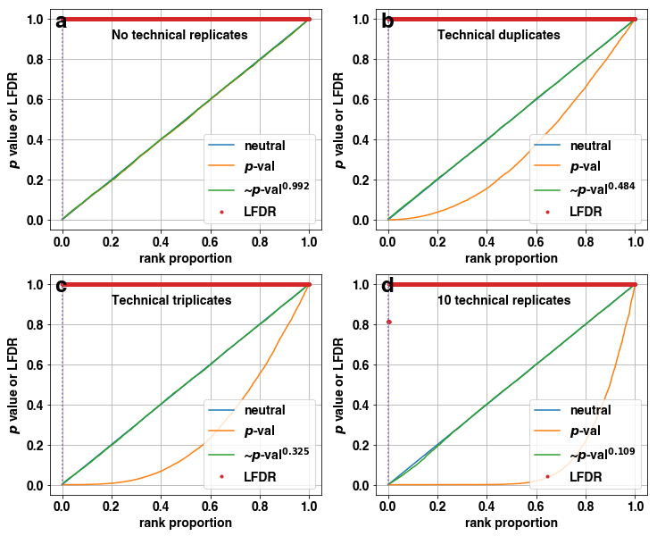

```python
figure(figsize=(12, 10))
subplot(221)
neup(aps1, LFDRthr0=LFDRthr0, minr0=0, subplot_label='a', plotLFDR=False, base_pop=bp1[0]);
text(0.2, 0.9, 'No technical replicates')

subplot(222)
neup(aps2, LFDRthr0=LFDRthr0, minr0=0, subplot_label='b', plotLFDR=False, base_pop=bp2[0]);
text(0.2, 0.9, 'Technical duplicates')

subplot(223)
neup(aps3, LFDRthr0=LFDRthr0, minr0=0, subplot_label='c', plotLFDR=False, base_pop=bp3[0]);
text(0.2, 0.9, 'Technical triplicates')

subplot(224)
neup(aps10, LFDRthr0=LFDRthr0, minr0=0, subplot_label='d', plotLFDR=False, base_pop=bp10[0]);
text(0.2, 0.9, '10 technical replicates')
```

## Supplementary Figure 4

### How do problems in data normalization distort p-value distribution in Student's t-test?

```python
N = 10000
data = create_simu_data(mdif=0, nrep=3, ntechrep=1, prop=1)
_, ps0 = ss.ttest_ind(data[0].values, data[1].values, equal_var=True, axis=1)

data = create_simu_data(mdif=1, nrep=3, ntechrep=1, prop=1)
_, ps1 = ss.ttest_ind(data[0].values, data[1].values, equal_var=True, axis=1)

data = create_simu_data(mdif=2, nrep=3, ntechrep=1, prop=1)
_, ps2 = ss.ttest_ind(data[0].values, data[1].values, equal_var=True, axis=1)

data = create_simu_data(mdif=3, nrep=3, ntechrep=1, prop=1)
_, ps3 = ss.ttest_ind(data[0].values, data[1].values, equal_var=True, axis=1)
```

```
iterations:0 r0:0.000, re:0.250, a:1.00174 lsq para:[ -1.46804595 -11.7640419 ]
finetune para: [1.0004348573327921, 0.0, 2.0]  raw aa: 1.00086990377
total iterations:0 r0:0.000, re:0.250, last a:1.00174
power of p-values: fit: 1.0004, base: 1.0000, final:1.0004
iterations:0 r0:0.011, re:0.258, a:0.53150 lsq para:[ 0.10627133  0.30432123]
iterations:1 r0:0.000, re:0.250, a:0.52371 lsq para:[ 0.1030032   0.28890103]
finetune para: [0.58620589452398564, 0.92232498193490486, 1.9963645225303825]  raw aa: 0.523713409718
total iterations:1 r0:0.000, re:0.250, last a:0.52371
power of p-values: fit: 0.5862, base: 1.0000, final:0.5862
iterations:0 r0:0.443, re:0.582, a:0.36739 lsq para:[ 0.55636132  1.13397837]
iterations:1 r0:0.000, re:0.250, a:0.24987 lsq para:[ 0.52100116  0.54271793]
finetune para: [0.33239925973284062, 1.0, 1.9860355393008149]  raw aa: 0.249870639378
total iterations:1 r0:0.000, re:0.250, last a:0.24987
power of p-values: fit: 0.3324, base: 1.0000, final:0.3324
iterations:0 r0:0.474, re:0.606, a:0.30498 lsq para:[ 0.68345273  0.94236064]
iterations:1 r0:0.000, re:0.250, a:0.22161 lsq para:[ 0.64116907  0.4606607 ]
finetune para: [0.25004864026030998, 0.99999999999999989, 1.976327387255421]  raw aa: 0.221612877282
total iterations:1 r0:0.000, re:0.250, last a:0.22161
power of p-values: fit: 0.2500, base: 1.0000, final:0.2500
```

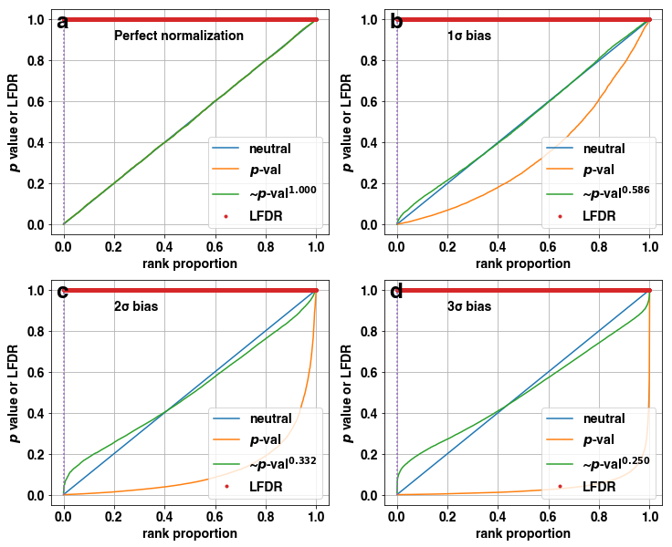

```python
figure(figsize=(12, 10))
subplot(221)
neup(ps0, LFDRthr0=LFDRthr0, minr0=0, subplot_label='a', plotLFDR=False);
text(0.2, 0.9, 'Perfect normalization')

subplot(222)
neup(ps1, LFDRthr0=LFDRthr0, minr0=0, subplot_label='b', plotLFDR=False);
text(0.2, 0.9, '1σ bias')

subplot(223)
neup(ps2, LFDRthr0=LFDRthr0, minr0=0, subplot_label='c', plotLFDR=False);
text(0.2, 0.9, '2σ bias')

subplot(224)
neup(ps3, LFDRthr0=LFDRthr0, minr0=0, subplot_label='d', plotLFDR=False);
text(0.2, 0.9, '3σ bias')
```

## Supplementary Figure 5

### How do global changes distort p-value distribution in Student's t-test?

For each "gene" in all genes, the expected change has the standard normal distribution.

```
iterations:0 r0:0.174, re:0.381, a:0.78410 lsq para:[ 0.06656998  0.19034375]
iterations:1 r0:0.000, re:0.250, a:0.58766 lsq para:[ 0.0018189   0.01723105]
finetune para: [0.590744925787968, -0.00013122539767497192, 2.0]  raw aa: 0.587663185863
total iterations:1 r0:0.000, re:0.250, last a:0.58766
power of p-values: fit: 0.5907, base: 1.0000, final:0.5907
iterations:0 r0:0.284, re:0.463, a:0.76940 lsq para:[ 0.06520443  0.11251879]
iterations:1 r0:0.165, re:0.374, a:0.61223 lsq para:[ 0.01149787 -0.04992527]
iterations:2 r0:0.000, re:0.250, a:0.46317 lsq para:[-0.02677466 -0.07645766]
finetune para: [0.45243264238438058, -0.14991431656233126, 1.9999428031809003]  raw aa: 0.4631675164
total iterations:2 r0:0.000, re:0.250, last a:0.46317
power of p-values: fit: 0.4524, base: 1.0000, final:0.4524
iterations:0 r0:0.369, re:0.527, a:0.71387 lsq para:[  4.49607857e-02  -9.24845299e-05]
iterations:1 r0:0.244, re:0.433, a:0.55159 lsq para:[ 0.01064171 -0.05657414]
iterations:2 r0:0.117, re:0.338, a:0.43505 lsq para:[-0.02601654 -0.15974887]
iterations:3 r0:0.000, re:0.250, a:0.35650 lsq para:[-0.05205348 -0.1474532 ]
finetune para: [0.33614550184375708, -0.23781818593409887, 1.9996583975651381]  raw aa: 0.356503734022
total iterations:3 r0:0.000, re:0.250, last a:0.35650
power of p-values: fit: 0.3361, base: 1.0000, final:0.3361
iterations:0 r0:0.523, re:0.643, a:0.61737 lsq para:[ 0.02609186 -0.00065006]
iterations:1 r0:0.383, re:0.537, a:0.42590 lsq para:[-0.01691177 -0.17304373]
iterations:2 r0:0.249, re:0.437, a:0.31793 lsq para:[-0.04964885 -0.22053479]
iterations:3 r0:0.119, re:0.339, a:0.24768 lsq para:[-0.07558633 -0.1802135 ]
iterations:4 r0:0.012, re:0.259, a:0.20561 lsq para:[-0.10146351 -0.18563291]
iterations:5 r0:0.000, re:0.250, a:0.20147 lsq para:[-0.10445226 -0.18675591]
finetune para: [0.17360373633246934, -0.301360251900745, 1.9997589499008286]  raw aa: 0.20147019246
total iterations:5 r0:0.000, re:0.250, last a:0.20147
power of p-values: fit: 0.1736, base: 1.0000, final:0.1736
```

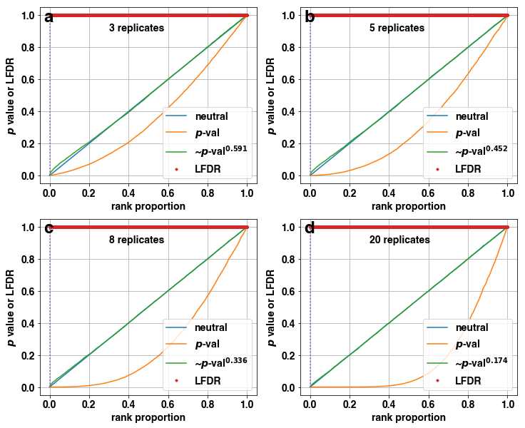

```python
figure(figsize=(12, 10))
N = 10000
# psg, zs, vbs = ascertained_ttest(datag , pre_neutralize=False, equalV=False, span=0.5, weights=weighted)
for i, nrep in enumerate([3, 5, 8, 20]):
    data = create_simu_data(mdif=0, nrep=nrep, ntechrep=1, prop=1, normal=True)
#     psn, zs, vbs = ascertained_ttest(data, pre_neutralize=False, equalV=True, span=0.5, weights=False)
    _, psn = ss.ttest_ind(data[0].values, data[1].values, equal_var=True, axis=1)
    subplot(221+i)
    neup(psn, LFDRthr0=LFDRthr0, minr0=0, subplot_label='abcd'[i], plotLFDR=False, fine_tune=True);
    text(0.3, 0.9, str(nrep)+' replicates')
```

## Supplementary Figure 6

### How do various proportions of changes distort p-value distribution in Welch's t-test and ascertained t-test?

For each "gene" in a proportion of all genes, the expected change has the standard normal distribution.

```python
N = 10000
pops = {}
props = [0.2, 0.4, 0.7, 1]
nreps = [3, 5, 8, 20]
for i, prop in enumerate(props):
    pops[prop] = {'Welch':[], 'ascertained':[]}
    for nrep in nreps:
        pops[prop]['Welch'].append([])
        pops[prop]['ascertained'].append([])
        for j in range(10):
            data = create_simu_data(mdif=0, nrep=nrep, ntechrep=1, prop=prop, normal=True)
            _, psn = ss.ttest_ind(data[0].values, data[1].values, equal_var=False, axis=1)
            _, _, pop = neup(psn, LFDRthr0=LFDRthr0, minr0=0, with_plot=False);
            pops[prop]['Welch'][-1].append(pop)
            psn, zs, vbs = ascertained_ttest(data, equalV=False, weights=False)
            _, _, pop = neup(psn, LFDRthr0=LFDRthr0, minr0=0, with_plot=False, base_pop=vbs['base_pop'][0]);
            pops[prop]['ascertained'][-1].append(pop)
```

```
0.935; 0.908; 0.953; 0.954; 0.942; 0.951; 0.947; 0.963; 0.937; 0.973; 0.871; 0.867; 0.877; 0.886; 0.901; 0.917; 0.875; 0.876; 0.87; 0.866; 0.877; 0.899; 0.903; 0.879; 0.882; 0.899; 0.899; 0.904; 0.878; 0.913; 0.929; 0.899; 0.906; 0.917; 0.902; 0.954; 0.908; 0.915; 0.918; 0.932; 0.858; 0.847; 0.845; …
```

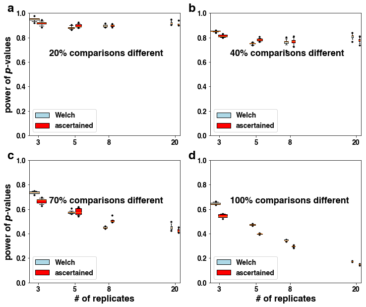

```python
figure(figsize=(12, 10))
for i, prop in enumerate(props):
    ax = subplot(221+i)
    args = {'whis':[10, 90], 'sym':'.k',  'widths':0.4, 'patch_artist':True}
    bp1 = boxplot(pops[prop]['Welch'],       positions=[p*0.95 for p in nreps], **args);
    for b in bp1['boxes']: b.set_facecolor('lightblue')
    bp2 = boxplot(pops[prop]['ascertained'], positions=[p*1.05 for p in nreps], **args);
    for b in bp2['boxes']: b.set_facecolor('red')
    ylim([0, 1])
#     xlim([0.0, 21])
    ax.set_xticklabels(nreps); ax.set_xscale('log', basex=2)
    ax.set_xticks(nreps)
    ax.get_xaxis().set_major_formatter(matplotlib.ticker.ScalarFormatter())
    text(3.5, 0.65, str(int(prop*100))+'% comparisons different', fontsize=18)
    text(1.95, 1.01, 'abcd'[i], fontsize=24, fontweight='bold')
    ax.legend([bp1["boxes"][0], bp2["boxes"][0]], ['Welch', 'ascertained'], loc='lower left')
    if i in [2, 3]: xlabel('# of replicates', fontweight='bold', fontsize=18)
    if i in [0, 2]: ylabel('power of $p$-values', fontweight='bold', fontsize=18)
```

```python
N = 10000
data = create_simu_data(0, 3, 1) #* range(N)
```

```
iterations:0 r0:0.000, re:0.250, a:0.98393 lsq para:[-0.49936867 -3.77054   ]
finetune para: [0.98937850192924892, -1.8470791019353783e-05, 2.0]  raw aa: 0.983928727714
total iterations:0 r0:0.000, re:0.250, last a:0.98393
power of p-values: fit: 0.9894, base: 1.0000, final:0.9894
shape (dimensions) of results: (10000, 4)
```

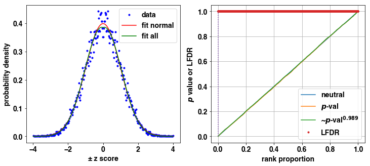

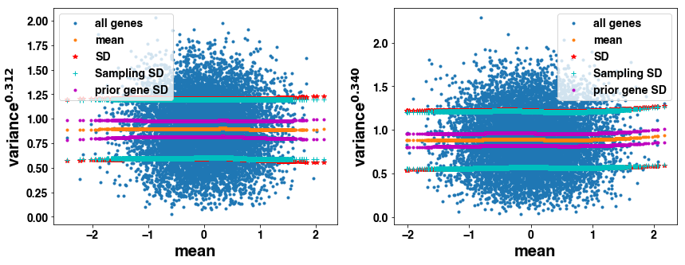

```python
res = count_analysis([data[0], data[1]], debug=True, span=0.9, weighted=False, pre_neutralize=False)
res.plot_variance()
```